# **CMU 16825 Learning for 3D Vision – Assignment 2 Submission**

## **Patrick Chen** *(Andrew ID: bochunc)*

### **Task 1: Exploring loss functions**

🔹**Fitting a voxel grid**  
🔹**Fitting a point cloud**  
🔹**Fitting a mesh**

### **Task 2: Reconstructing 3D from single view**

🔹**Image to voxel grid**  
🔹**Image to point cloud**  
🔹**Image to mesh**  
🔹**Quantitative comparisions**  
🔹**Analyse effects of hyperparams variations**  
🔹**Interpret your model**

### **Task 3: Exploring other architectures / datasets.**

🔹**Implicit network**  
🔹**Extended dataset for training**

## Task 1.1: Fitting a voxel grid (5 points)

The following shows the optimized voxel grid and the ground truth:

Optimized

Ground Truth

[figure not shown]

[figure not shown]

## Task 1.2: Fitting a point cloud (5 points)

The following shows the optimized point cloud and the ground truth:

Optimized

Ground Truth

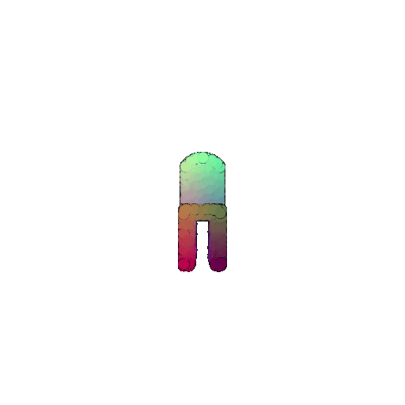

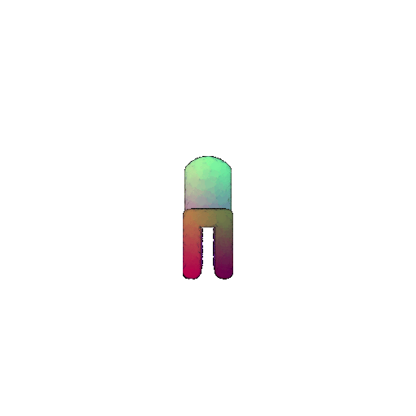

## Task 1.3: Fitting a mesh (5 points)

The following shows the optimized mesh and the ground truth:

Optimized

Ground Truth

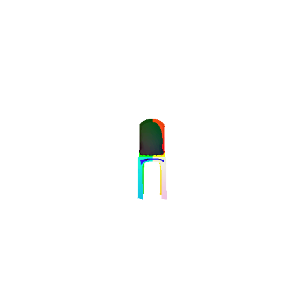

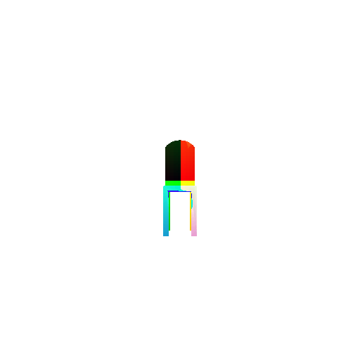

## Task 2.1: Image to voxel grid (20 points)

The following shows the input RGB image, the ground truth mesh, the ground truth 3D voxel, and the render of predicted 3D voxel:

Input RGB Image

Ground Truth Mesh

Ground Truth 3D Voxel

Predicted 3D Voxel

[figure not shown]

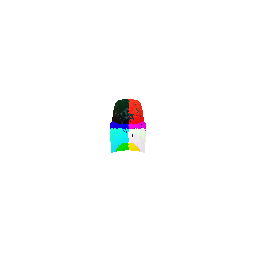

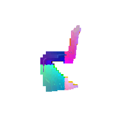

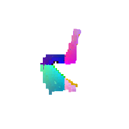

Input RGB Image

Ground Truth Mesh

Ground Truth 3D Voxel

Predicted 3D Voxel

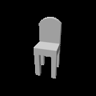

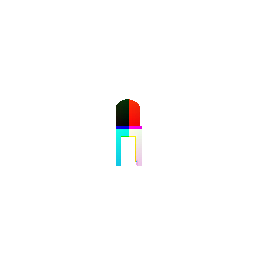

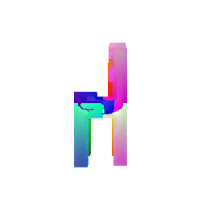

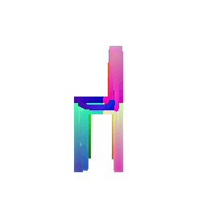

Input RGB Image

Ground Truth Mesh

Ground Truth 3D Voxel

Predicted 3D Voxel

[figure not shown]

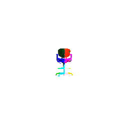

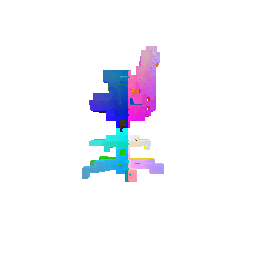

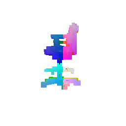

## Task 2.2: Image to point cloud (20 points)

The following shows the input RGB image, the ground truth mesh, the ground truth 3D point cloud, and the render of predicted 3D point cloud:

Input RGB Image

Ground Truth Mesh

Ground Truth 3D Point Cloud

Predicted 3D Point Cloud

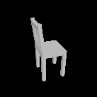

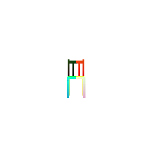

[figure not shown]

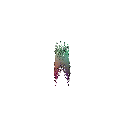

Input RGB Image

Ground Truth Mesh

Ground Truth 3D Point Cloud

Predicted 3D Point Cloud

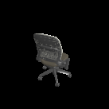

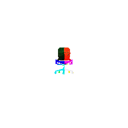

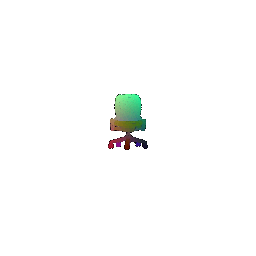

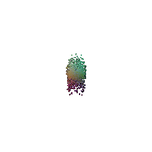

Input RGB Image

Ground Truth Mesh

Ground Truth 3D Point Cloud

Predicted 3D Point Cloud

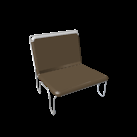

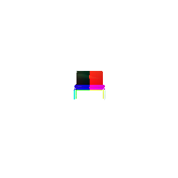

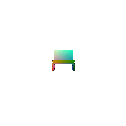

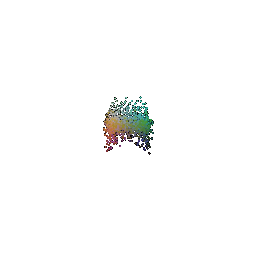